# Aisha

Aisha

November 8, 2018

## Sumbission 1

1. The names of all team members that worked on the document.
2. An overview of the data set you are working with for the final project
3. A discussion of cleaning steps that are necessary to get the data into the right shape

1. Lynn Hyuang, Prateek Oberoi, Aisha Washington
2. We are working with TMDB_5000_Movie Dataset from The Movie Database. There are two tables: One with information on various aspects of movies such as an identifier number for each movie, the title, the cast, and the crew; the second with information on the budget, genres,revenue, and other items specific to the movie’s audience facing perception.
3. Selecting variables of interest: We can use select statements in order to work with only the factors that we’re interested in.  
   Separating genres and keywords from filler text: Since the genre and keyword categories are often different for each observation, we can use regular expressions in order to create a genereal formula for what needs to be removed, select variables of interest

# Separate Dense Variables

```r
library(tidyverse)
```

```r
library(stringr)
library(ggplot2)

credits <- read.csv('tmdb_5000_credits.csv')
str(credits)
```

```
## 'data.frame':    4803 obs. of  4 variables:
##  $ movie_id: int  19995 285 206647 49026 49529 559 38757 99861 767 209112 ...
##  $ title   : Factor w/ 4800 levels "#Horror","(500) Days of Summer",..: 381 2653 3186 3614 1906 3198 3364 382 1587 444 ...
##  $ cast    : Factor w/ 4761 levels "[]","[{\"cast_id\": 0, \"character\": \"\", \"credit_id\": \"535c33ef0e0a264fe1001e97\", \"gender\": 2, \"id\": 6349"| __truncated__,..: 3230 3813 843 2637 4194 3731 3756 4532 3457 2485 ...
##  $ crew    : Factor w/ 4776 levels "[]","[{\"credit_id\": \"52fe420dc3a36847f800012d\", \"department\": \"Directing\", \"gender\": 1, \"id\": 3110, \"jo"| __truncated__,..: 2601 109 3419 2498 2525 202 2357 3855 301 3630 ...
```

```r
movies <- read.csv('tmdb_5000_movies.csv')
str(movies)
```

```
## 'data.frame':    4803 obs. of  20 variables:
##  $ budget              : int  237000000 300000000 245000000 250000000 260000000 258000000 260000000 280000000 250000000 250000000 ...
##  $ genres              : Factor w/ 1175 levels "[]","[{\"id\": 10402, \"name\": \"Music\"}, {\"id\": 10749, \"name\": \"Romance\"}]",..: 609 144 675 792 678 301 341 678 124 610 ...
##  $ homepage            : Factor w/ 1692 levels "","http://2016themovie.com/",..: 462 58 1282 1379 219 1285 66 192 138 475 ...
##  $ id                  : int  19995 285 206647 49026 49529 559 38757 99861 767 209112 ...
##  $ keywords            : Factor w/ 4222 levels "[]","[{\"id\": 100, \"name\": \"slum\"}, {\"id\": 1009, \"name\": \"baby\"}, {\"id\": 1721, \"name\": \"fight\"}, {\"| __truncated__,..: 535 1609 2618 3893 3779 3895 633 3923 3245 3891 ...
##  $ original_language   : Factor w/ 37 levels "af","ar","cn",..: 8 8 8 8 8 8 8 8 8 8 ...
##  $ original_title      : Factor w/ 4801 levels "#Horror","$upercapitalist",..: 414 2748 3272 3674 1970 3284 3445 415 1642 477 ...
##  $ overview            : Factor w/ 4801 levels "","'Breaking Upwards' explores a young, real-life New York couple who, four years in and battling codependency, de"| __truncated__,..: 2526 1666 168 2082 2801 3918 4638 4671 1417 2042 ...
##  $ popularity          : num  150.4 139.1 107.4 112.3 43.9 ...
##  $ production_companies: Factor w/ 3697 levels "[]","[{\"name\": \"100 Bares\", \"id\": 5517}, {\"name\": \"Haddock Films S.R.L.\", \"id\": 5623}, {\"name\": \"Inst"| __truncated__,..: 1395 3541 528 1563 3578 566 3568 1700 3606 724 ...
##  $ production_countries: Factor w/ 469 levels "[]","[{\"iso_3166_1\": \"AE\", \"name\": \"United Arab Emirates\"}, {\"iso_3166_1\": \"GB\", \"name\": \"United King"| __truncated__,..: 441 466 300 466 466 466 466 466 300 466 ...
##  $ release_date        : Factor w/ 3281 levels "","1916-09-04",..: 2315 1945 3185 2688 2635 1940 2450 3111 2246 3234 ...
##  $ revenue             : num  2.79e+09 9.61e+08 8.81e+08 1.08e+09 2.84e+08 ...
##  $ runtime             : num  162 169 148 165 132 139 100 141 153 151 ...
##  $ spoken_languages    : Factor w/ 544 levels "[]","[{\"iso_639_1\": \"af\", \"name\": \"Afrikaans\"}, {\"iso_639_1\": \"en\", \"name\": \"English\"}, {\"iso_639_1"| __truncated__,..: 180 384 404 384 384 252 384 384 384 384 ...
##  $ status              : Factor w/ 3 levels "Post Production",..: 2 2 2 2 2 2 2 2 2 2 ...
##  $ tagline             : Factor w/ 3945 levels "","'Til death do they party...",..: 740 418 194 2840 1834 2665 3239 178 641 1701 ...
##  $ title               : Factor w/ 4800 levels "#Horror","(500) Days of Summer",..: 381 2653 3186 3614 1906 3198 3364 382 1587 444 ...
##  $ vote_average        : num  7.2 6.9 6.3 7.6 6.1 5.9 7.4 7.3 7.4 5.7 ...
##  $ vote_count          : int  11800 4500 4466 9106 2124 3576 3330 6767 5293 7004 ...
```

### Clean Credits

- Seperate credits into `cast1` - `cast5`

```r
credits1 <- credits %>%
  select(-crew) %>%
  separate(cast, into = c('cast1','cast2','cast3','cast4','cast5'), sep = '\\}, \\{')
credits1$cast1 <- sub("(?:\\[\\{)?\"cast_id\": \\d+, \"character\": \"\\w+(?:..)*(?: \\w+)*\", \"credit_id\": \"\\w+\", \"gender\": \\d, \"id\": \\d+, \"name\": \"(\\w+(?:..)*(?: \\w+.))*\", \"order\": \\d", "\\1", credits1$cast1)
credits1$cast2 <- sub("(?:\\[\\{)?\"cast_id\": \\d+, \"character\": \"\\w+(?:..)*(?: \\w+)*\", \"credit_id\": \"\\w+\", \"gender\": \\d, \"id\": \\d+, \"name\": \"(\\w+(?:..)*(?: \\w+.))*\", \"order\": \\d", "\\1", credits1$cast2)
credits1$cast3 <- sub("(?:\\[\\{)?\"cast_id\": \\d+, \"character\": \"\\w+(?:..)*(?: \\w+)*\", \"credit_id\": \"\\w+\", \"gender\": \\d, \"id\": \\d+, \"name\": \"(\\w+(?:..)*(?: \\w+.))*\", \"order\": \\d", "\\1", credits1$cast3)
credits1$cast4 <- sub("(?:\\[\\{)?\"cast_id\": \\d+, \"character\": \"\\w+(?:..)*(?: \\w+)*\", \"credit_id\": \"\\w+\", \"gender\": \\d, \"id\": \\d+, \"name\": \"(\\w+(?:..)*(?: \\w+.))*\", \"order\": \\d", "\\1", credits1$cast4)
credits1$cast5 <- sub("(?:\\[\\{)?\"cast_id\": \\d+, \"character\": \"\\w+(?:..)*(?: \\w+)*\", \"credit_id\": \"\\w+\", \"gender\": \\d, \"id\": \\d+, \"name\": \"(\\w+(?:..)*(?: \\w+.))*\", \"order\": \\d", "\\1", credits1$cast5)

write.csv(credits1, 'credits_separated.csv')
```

### Clean Movies

- Separate Genre into `genre1`, `genre2`, `genre3`
- Create `main_production`, `main_country`, `main_language`
- Scale `budget` and `revenue` to be per million

```r
# Select  variables of interest / capture first 3 genres
movies1 <- movies %>%
  select(budget, genres, original_title, popularity, production_companies, production_countries, release_date, revenue, runtime, spoken_languages, vote_average, vote_count) %>%
  separate(genres, into = c('genre1','genre2','genre3'), sep = '\\}, \\{')
movies1$genre1 <- sub("(\\[\\{)?\"id\": \\d+, \"name\": \"(\\w+ ?\\w+?)\"(\\}\\])?", '\\2', movies1$genre1)
movies1$genre2 <- sub("(\\[\\{)?\"id\": \\d+, \"name\": \"(\\w+ ?\\w+?)\"(\\}\\])?", '\\2', movies1$genre2)
movies1$genre3 <- sub("(\\[\\{)?\"id\": \\d+, \"name\": \"(\\w+ ?\\w+?)\"(\\}\\])?", '\\2', movies1$genre3)

# Capture first production company
movies2 <- movies1 %>%
  separate(production_companies, into = c('main_production'), sep = '\\}, \\{')
movies2$main_production <- sub("\\[\\{\"name\": \"(\\w+.\\w+(?:.+)*)\", \"id\": \\d+", '\\1', movies2$main_production)
movies2$main_production <- str_remove_all(movies2$main_production, '\\}\\]')

# Capture first production countries
movies3 <- movies2 %>%
  separate(production_countries, into = c('main_country'), sep = '\\}, \\{')
movies3$main_country <-sub("\\[\\{\"iso_3166_1\": \"\\w+\", \"name\": \"(\\w+(?: \\w+.)*)\"(?:\\}\\])?", '\\1', movies3$main_country)

# Capture first language
movies4 <- movies3 %>% separate(spoken_languages, into = 'main_language', sep = '\\}, \\{')
movies4$main_language <-sub('\\[\\{"iso_639_1": "(\\w{2})", "name": ".*"(?:\\}\\])?', '\\1', movies4$main_language)

# Scale Budget and Revenue to Per Million (Remove)
movies4$budget <- movies4$budget / 10^6
movies4$revenue <- movies4$revenue / 10^6

str(movies4)
```

```
## 'data.frame':    4803 obs. of  14 variables:
##  $ budget         : num  237 300 245 250 260 258 260 280 250 250 ...
##  $ genre1         : chr  "Action" "Adventure" "Action" "Action" ...
##  $ genre2         : chr  "Adventure" "Fantasy" "Adventure" "Crime" ...
##  $ genre3         : chr  "Fantasy" "Action" "Crime" "Drama" ...
##  $ original_title : Factor w/ 4801 levels "#Horror","$upercapitalist",..: 414 2748 3272 3674 1970 3284 3445 415 1642 477 ...
##  $ popularity     : num  150.4 139.1 107.4 112.3 43.9 ...
##  $ main_production: chr  "Ingenious Film Partners" "Walt Disney Pictures" "Columbia Pictures" "Legendary Pictures" ...
##  $ main_country   : chr  "United States of America" "United States of America" "United Kingdom" "United States of America" ...
##  $ release_date   : Factor w/ 3281 levels "","1916-09-04",..: 2315 1945 3185 2688 2635 1940 2450 3111 2246 3234 ...
##  $ revenue        : num  2788 961 881 1085 284 ...
##  $ runtime        : num  162 169 148 165 132 139 100 141 153 151 ...
##  $ main_language  : chr  "en" "en" "fr" "en" ...
##  $ vote_average   : num  7.2 6.9 6.3 7.6 6.1 5.9 7.4 7.3 7.4 5.7 ...
##  $ vote_count     : int  11800 4500 4466 9106 2124 3576 3330 6767 5293 7004 ...
```

```r
write.csv(movies4, 'movies_separated.csv')
```

# Analysis

- Are there any production companies that have higher budgets than others, on average?
- If so , how do their movies compare in terms and `revenue`?

```r
mov <- read.csv('movies_separated.csv')
mov <- mov %>% filter(budget > 0)
#mov %>% head()
```

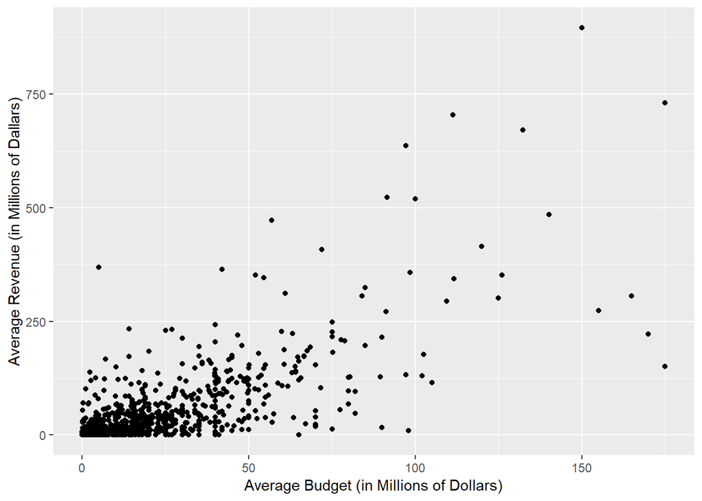

Above we have a scatter plot of average budget against the average revenue for each production company. As the budget increases, so does the expected revenue. However as the budget increase, the variance in returns also increases. Mega movies, defined as movies with budgets greater than $100 million, have potential to earn much higher profits, however they also have potential for higher losses.

### *High Budget Production Companies*

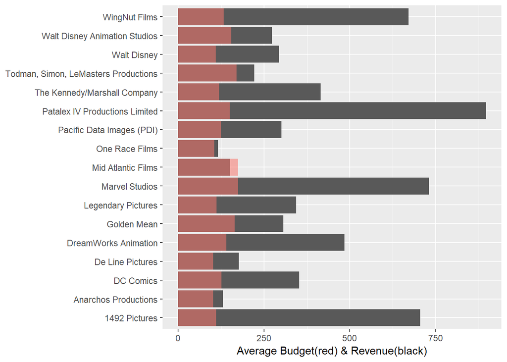

There are 17 production companies that have the average buget of a mega movie. On average, all but one of them make more than they spend in revenue.

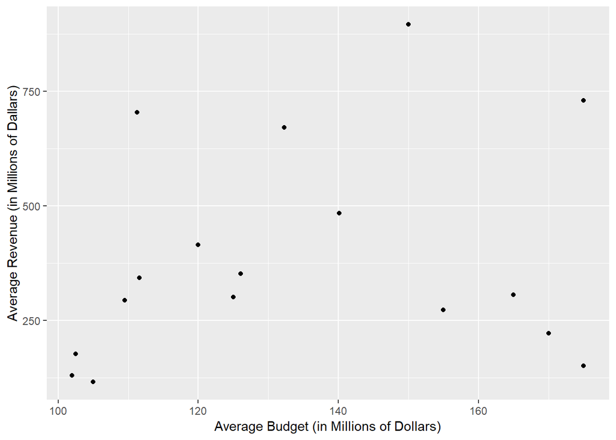

Of the mega movie production companies, after spending $100 million on a project, there is no impact on revenue. There may be a small positive relationship between budget and revenue, but it is masked by the variance.

### *Average Budget Production Companies*

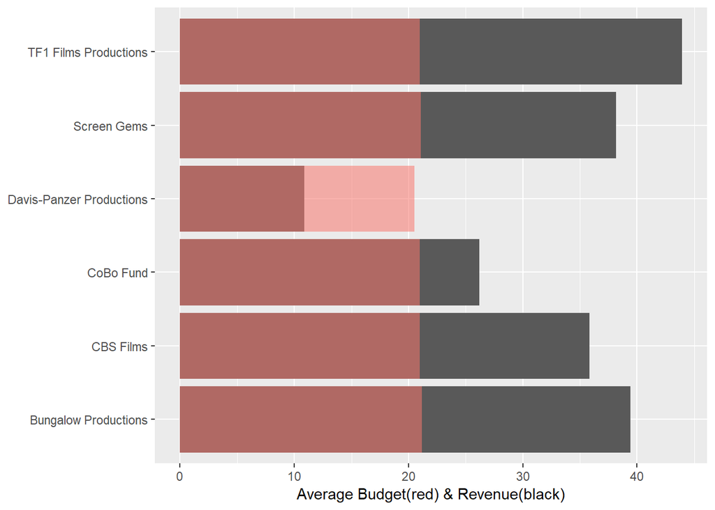

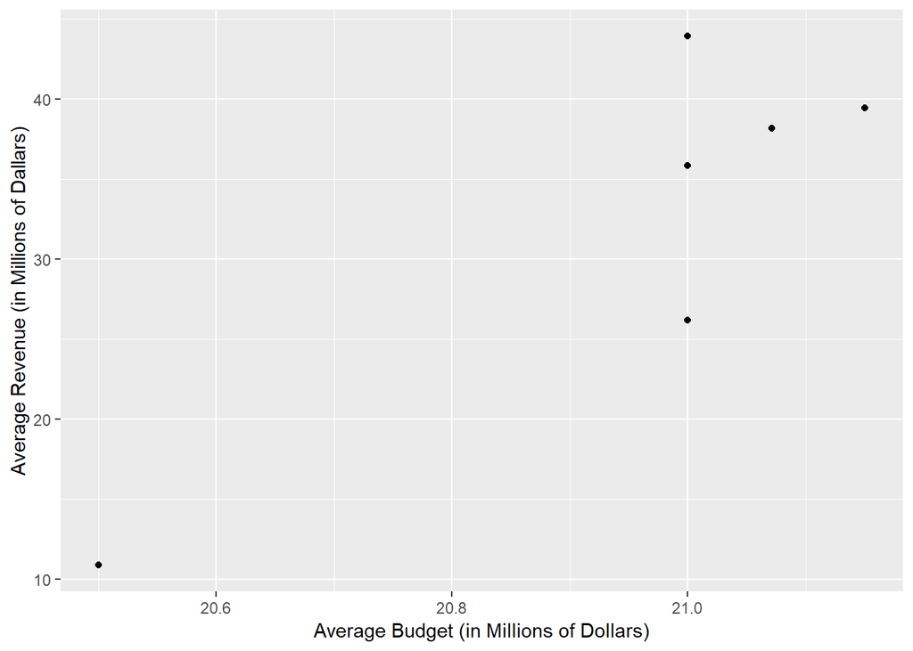

We have fewer companies shown than in the mega movie category. There appears to be a slight positive relationship between budget and revenue.

### *Low Budget Production Companies*

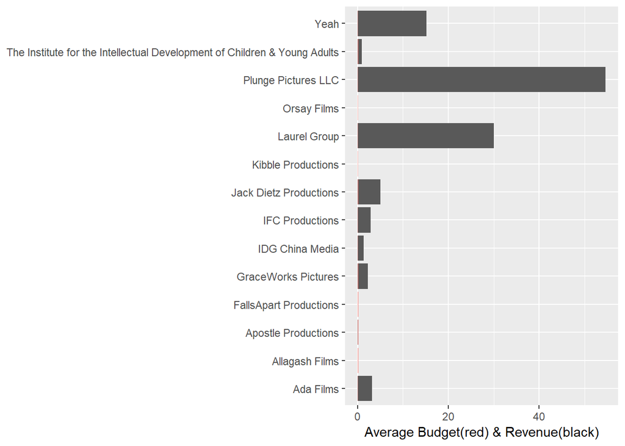

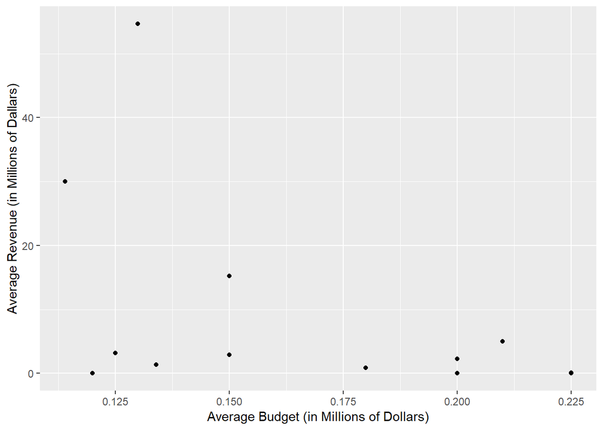

There are 14 low budget films, defined as movies with budgets below $250,000. Of these production companies they mostly have much higher revenues than the movies cost to produce. Orsey Films, Kibble, FallsApart, Apostle, and Allagash Films have revenues close to the budget (or below).

### Compare Mega, Average, and Low Budget Production Companies

```r
# Subset Budget groups
highsub <- mov %>% filter(main_production %in% c('1492 Pictures', 'Anarchos Productions', 'DC Comics', 'De Line Pictures', 'DreamWorks Animation', 'Legendary Pictures', 'Marvel Studios', 'Mid Atlantic Films', 'One Race Films', 'Pacific Data Images', 'Patalex IV Productions Limited', 'Todman, Simon, LeMasters Productions', 'Walt Disney Animation Studios', 'Walt Disney', 'WingNut Films')) %>% mutate(sub = 'High')

avgsub <- mov %>% filter(main_production %in% c('Working Title Films', 'Wild Bunch', 'This Is That Productions','River Road Entertainment', 'Production One', 'Paul Schiff Productions', 'Participant Media', 'Mike Zoss Productions', 'Metro-Goldwyn-Mayer (MGM)', 'Ghost House Pictures')) %>% mutate(sub = 'Average')

lowsub <- mov %>% filter(main_production %in% c('Yeah', 'The Institute for the Intellectual Development of Children & Young Adults', 'Plunge Pictures LLC', 'Orsay Films', 'Laurel Group', 'Kibble Productions', 'Jack Dietz Productions', 'IFC Productions', 'IDG China Media', 'GraceWorks Pictures', 'FallsApart Productions', 'Apostle Productions', 'Allagash Films', 'Ada Films')) %>% mutate(sub = 'Low')

# Create return on investment metric (revenue/budget)
sub <- rbind(highsub, avgsub, lowsub) %>%
  mutate(return = revenue/budget) %>%
  select(sub, original_title, main_production, budget, revenue, return)
sub$sub <- factor(sub$sub, levels = c('High', 'Average', 'Low'))
```

```r
sub %>% group_by(sub) %>%
  summarise(return = mean(return), rev = mean(revenue))
```

```
## # A tibble: 3 x 3
##   sub     return    rev
##   <fct>    <dbl>  <dbl>
## 1 High      3.55 458.
## 2 Average   3.97  31.5
## 3 Low      62.9    8.26
```

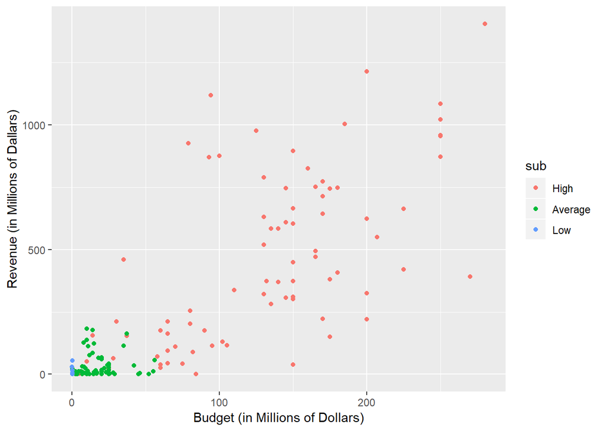

If the goal is to have the highest revenue, then a mega producer will churn out the highest. However for the highest return, low budget films are more effective.